# Reporte

Genoveva

2024-04-05

# **Análisis de la frecuencia en el uso de dispositivos tecnológicos**

## 1. Objetivo.

Obtener información respecto a la frecuencia de uso de dispositivos tecnológicos y el tiempo invertido en la realización de tareas o trabajos escolares, en proporcionalidad con la edad y el grado de escolaridad.

## 2. Justificación.

El presente análisis expone datos, por edad y escolaridad, respecto a la frecuencia en el uso de dispositivos como smartphone y laptop, para poder verificar si el grado académico influye en el tiempo que se invierte en la realización de tareas o trabajos escolares.

## 3. Análisis exploratorio de los datos (estadística descriptiva).

De conformidad con la Encuesta Nacional sobre el uso y disponibilidad de las TIC en los hogares, realizada por el INEGI, en 2021 el uso de teléfonos inteligentes para la realización de actividdes escolares ha aumentado, en comparación con el uso de equipos portátiles.

Para llevar a cabo el análisis de los datos se ralizaron los siguientes pasos:

- Extracción del archivo origen del portal del INEGI.
- Cambio de nombre al archivo.
- Creación de subset con las columnas necesarias (solo seis datos).
- Renombre de columnas para una mejor identificación de los datos.
- Visualización de las primeras filas del nuevo dataframe.

Como se muestra a continuación:

```r
datos <- read.csv("conjunto_de_datos_tmodulo_enape_2021.csv")
head(datos)
```

```
##   FOLIO N_REN SEXO EDAD P3_1 P3_2 PA3_1 PA3_2 PA3_3_NIVEL PA3_3_BIMESTRE
## 1     2     1    1   13    2   NA     1     1           3             NA
## 2     2     2    2   19    2   NA     1     1           9             NA
## 3     7     1    2    8    2   NA     1     1           3             NA
## 4     7     2    1   26    7   NA     2    NA          NA             NA
## 5     9     1    1   27    1   NA     1     2           9             NA
## 6    11     1    2   24   10   NA     2    NA          NA             NA
##   PA3_3_TRIMESTRE PA3_3_CUATRIMESTRE PA3_3_SEMESTRE PA3_3_ANIO PA3_3_MODMAT
## 1              NA                 NA             NA          6           NA
## 2              NA                 NA             NA          1           NA
## 3              NA                 NA             NA          2           NA
## 4              NA                 NA             NA         NA           NA
## 5              NA                  2             NA         NA           NA
## 6              NA                 NA             NA         NA           NA
##   PA3_4 PA3_5 PA3_6 PA3_7_1 PA3_7_2 PA3_7_3 PA3_8_1 PA3_8_2 PA3_8_3 PA3_8_4
```

[output cut: 69 more lines]

```r
datos_filtrados <- subset(datos, select = c(FOLIO, EDAD, PB3_12_1, PB3_12_2, PB3_14, ESC))
head(datos_filtrados)
```

```
##   FOLIO EDAD PB3_12_1 PB3_12_2 PB3_14 ESC
## 1     2   13        2        1      0   2
## 2     2   19        2        1     NA   5
## 3     7    8        1        2     40   2
## 4     7   26       NA       NA     NA   4
## 5     9   27        2        1     NA   5
## 6    11   24       NA       NA     NA   5
```

```r
names(datos_filtrados) <- c("Id", "Edad", "Uso_smartphone", "Uso_laptop", "Horas_dedicadas","Escolaridad")
head(datos_filtrados)
```

```
##   Id Edad Uso_smartphone Uso_laptop Horas_dedicadas Escolaridad
## 1  2   13              2          1               0           2
## 2  2   19              2          1              NA           5
## 3  7    8              1          2              40           2
## 4  7   26             NA         NA              NA           4
## 5  9   27              2          1              NA           5
## 6 11   24             NA         NA              NA           5
```

## 4. Análisis estadístico inferencial.

```r
cor.test(datos_filtrados$Edad, datos_filtrados$Horas_dedicadas)
```

```
##
##  Pearson's product-moment correlation
##
## data:  datos_filtrados$Edad and datos_filtrados$Horas_dedicadas
## t = -14.96, df = 12303, p-value < 2.2e-16
## alternative hypothesis: true correlation is not equal to 0
## 95 percent confidence interval:
##  -0.1509769 -0.1162698
## sample estimates:
##        cor
## -0.1336643
```

```r
cor.test(datos_filtrados$Uso_smartphone, datos_filtrados$Uso_laptop)
```

```
##
##  Pearson's product-moment correlation
##
## data:  datos_filtrados$Uso_smartphone and datos_filtrados$Uso_laptop
## t = 4.6533, df = 19637, p-value = 3.288e-06
## alternative hypothesis: true correlation is not equal to 0
## 95 percent confidence interval:
##  0.01921100 0.04715217
## sample estimates:
##        cor
## 0.03318807
```

```r
modelo_anova <- aov(Horas_dedicadas ~ Escolaridad, data = datos_filtrados)
summary(modelo_anova)
```

```
##                Df Sum Sq Mean Sq F value Pr(>F)
## Escolaridad     1   4249    4249   124.2 <2e-16 ***
## Residuals   12303 420807      34
## ---
## Signif. codes:  0 '***' 0.001 '**' 0.01 '*' 0.05 '.' 0.1 ' ' 1
## 20038 observations deleted due to missingness
```

```r
tabla_frecuencias <- table(datos_filtrados$Uso_smartphone, datos_filtrados$Uso_laptop)
tabla_frecuencias
```

```
##
##        1    2
##   1 4884 9400
##   2 1643 3712
```

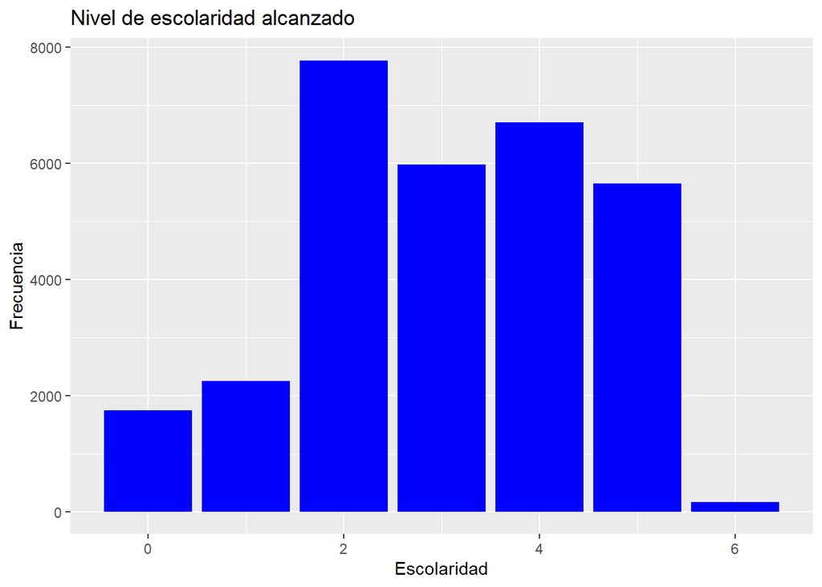

```r
library(ggplot2)
ggplot(datos_filtrados, aes(x = Escolaridad)) +
  geom_bar(fill = "blue") +
  labs(title = "Nivel de escolaridad alcanzado", x = "Escolaridad", y = "Frecuencia")
```

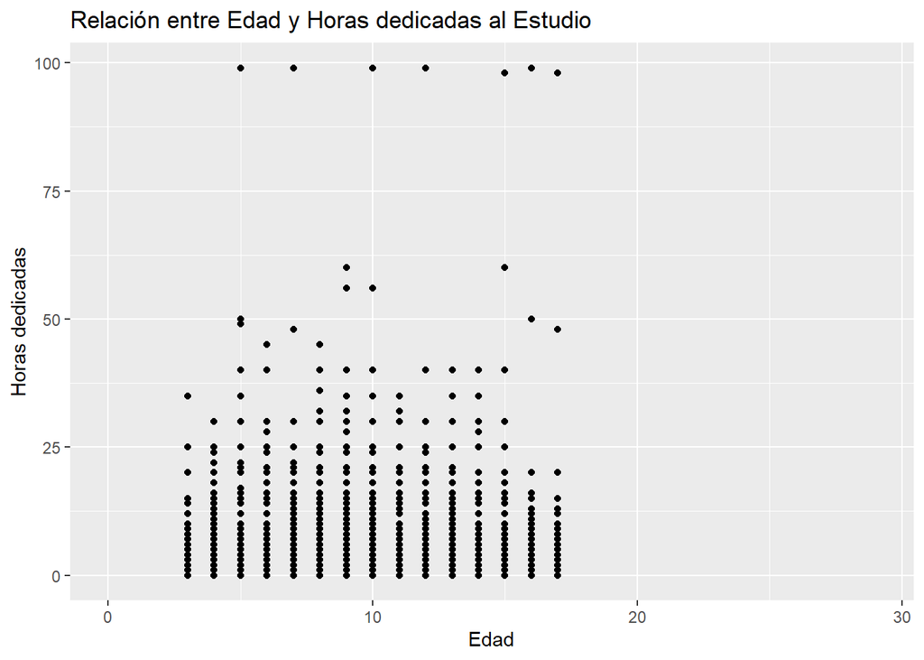

```r
ggplot(datos_filtrados, aes(x = Edad, y = Horas_dedicadas)) +
  geom_point() +
  labs(title = "Relación entre Edad y Horas dedicadas al Estudio", x = "Edad", y = "Horas dedicadas")
```

[figure not shown]

```r
ggplot(datos_filtrados, aes(x = Uso_smartphone, fill = Uso_laptop)) +
  geom_bar(position = "stack") +
  labs(title = "Uso de Smartphone y Laptop", x = "Uso de Smartphone", y = "Frecuencia") +
  scale_fill_manual(values = c("#AC769E", "blue"))
```